# Predicting Ductal Invasive Carcinomas via CNN

Eduardo Coronado

5/22/2019

*Example and code based on:*

- Baruah, Bikram, and Bikram Baruah. “Predicting Invasive Ductal Carcinoma Using Convolutional Neural Network (CNN) in Keras.” Towards Data Science, Towards Data Science, 3 Jan. 2019, towardsdatascience.com/predicting-invasive-ductal-carcinoma-using-convolutional-neural-network-cnn-in-keras-debb429de9a6.
- Choosehappy. “Use Case 6: Invasive Ductal Carcinoma (IDC) Segmentation.” Andrew Janowczyk, 5 Jan. 2018, www.andrewjanowczyk.com/use-case-6-invasive-ductal-carcinoma-idc-segmentation/.

#### **Before starting the exercise**

If you’d like to quickly knit an example using pre-computed data please download and unzip the files found in [**this link**](https://duke.box.com/s/4ouru5cu3b9sg7bn375st7m2nhfrkdyt).

Otherwise, uncomment the line with the `extract_carcinoma_data` helper function.  
This will take a couple of hour to run but will generate both the data and cache files for easy tuning of the model if needed.

### 1. Dataset

Given image files are large and require memory storage, we will focus on exploring a subset. This was done using a custom function `extract_carcinoma_data` which downloads the 1.6 Gb patches file, randomly selects `n` images and stores these in a temporary directory `data_idc`. The number of files to select can be specified using the `files_to_keep` variable, **but it is not recommended you select more than 100,000** as this will require to load around 2 Gb of data onto your RAM memory. Additionally, the helper function conducts some environment cleaning routines to remove unnecessary variables.

```r
# Check if data directories exists in current repo, if not
# download for original data file and pre process images
# for TRAIN and TEST folders
subdir <- "invasive-carcinoma"
data_dir <- file.path(here(), subdir, "data_idc")
train_dir <- file.path(here(), subdir, "TRAIN")
test_dir <- file.path(here(), subdir, "TEST")
files_to_keep <- 35000

# Helper function that downloads original data,
# extracts necessary data and stores it in respective folder

# extract_carcinoma_data(subdir, train_dir, test_dir, files_to_keep )

# Use pre-processed data instead of starting from scratch (35k patches)
# If changes are needed or would like to start from original 1.6 Gb file,
# uncomment the "extract_carcinoma..." line above
```

After the files to analyze are selected some further processing must happen given some patches are not the correct dimensions needed for analysis - 50x50x3 - where 50x50 is the pixel dimensions and 3 refers to a RGB color spectrum (e.g. for black and white you’d see a 50x50x1).

This task is done via the `process_images` custom function. It first lists the files in `data_idc`, splits them into malignant vs benign based on the filename terminations (i.e. “…class0”" for benign or “…class1” for malignant). Then the images are read one at a time, reshaped into 50x50x3 arrays with normalized pixel values between 0 and 1. Afterward it stores the image classification as `0` or `1` depending on the whether the processed image was benign or malignant, respectively.

```r
# Get file paths of all image patches saves as PNGs in data directory
image_patches <- list.files(data_dir, pattern = "*.png", recursive = TRUE,
                             full.names = TRUE)

#From all files, create subsets of those that are classified as malignant(1),
# or benign(0)
class_zero <- list.files(data_dir, pattern = "*class0.png", recursive = TRUE,
                         full.names = TRUE)
class_one  <-  list.files(data_dir, pattern = "*class1.png", recursive = TRUE,
                         full.names = TRUE)

# Helper function to preprocess images, not all in original zip
# are 50x50 color images (50,50,3)
process_images <-  function(lower_idx, upper_idx){

  img_width = img_height <- 50 # image width and height
  channels <- 3 # 3 channels = color, 1 channel = BW
  p <- progress_estimated(upper_idx) # set progress bar

  # Pre-allocate space for efficiency
  X <- array(NA, dim= c(upper_idx, img_width, img_height, channels))
  y <- rep(NA, upper_idx)

  # Loop over all PNG files and load them as normalized (50, 50, 3) matrices
  for (i in lower_idx:upper_idx){
    # Store images as matrices and normalize to get values between 0-1
    X[i,,,] <- image_load(image_patches[i], target_size = c(img_width, img_height),
                     interpolation = "bicubic") %>%
    image_to_array(.) * (1/255)

    # Now, if image is malignant or benign store its classification accordintly
    if(image_patches[i] %in% class_zero){
      y[i] <- "0"
    } else {
      y[i] <- "1"
    }

    p$tick()$print()
  }

  return(list(X,y)) # return X,y objects

}
```

```r
# Run helper function for all images data directory,
# however inputs allow to pre-process subsets via a
# lower and upper index bounds
x_y <- process_images(1,length(image_patches))
```

Now that we have all the data we must check for class imbalance (i.e. if the number of 0s and 1s are the same or not). This is important to reduce model bias since data imbalance can cause the model to incorrectly classify the minority class and the majority class (i.e. classify malignant as benign).

From the table below we can observe there are more benign cases in our subset. We will address this later using an R package.

```r
# Extract preprocessing output
X <- x_y[[1]]
Y <- x_y[[2]]

# Create table to show num of classes stored and
# preprocessed - NOTE: this shows class imbalance
kable(table(Y) %>% t())
```

| 0 | 1 |
| --- | --- |
| 25066 | 9934 |

First, we split our subset into training and test data (85% and 15% respectively).

```r
# Train / Test split
samp_size <- dim(X)[1] # number of files preprocesses (e.g. 100,000)

# 15-85 test/train split indexes
train <- sample(seq_len(samp_size), size = 0.85 * samp_size)

# Store train and test splits for both class and features
X_train <- X[train,,,]
X_test  <- X[-train,,,]
y_train <- Y[train]
y_test  <- Y[-train]

# Clean-up and save space
rm(X, Y, x_y, class_one,
   class_zero)
```

Now to tackle the class imbalance we will use the `caret` R-package. However, the function we will use doesn’t take in an multidimensional array (e.g. 50x50x3) and instead takes an `n`x`m` table/matrix. Therefore, we must flatten the arrays into 1 x `m` rows and stack them together.

```r
# First reshape matrices to feed into function to
# tackle imbalance
nobs_train <- dim(X_train)[1]
nobs_test  <- dim(X_test)[1]

# Shape of new rows will be (1, 50*50*3) = (1, 7500)
X_train_shape <- (dim(X_train)[2]^2) * dim(X_train)[4]
X_test_shape  <- (dim(X_test)[2]^2) * dim(X_test)[4]

# For each array, reshape it as (1, 7500) and stack into dataframe
X_train <- array_reshape(X_train,
                         dim = c(nobs_train, X_train_shape)) %>% as_tibble()
X_test  <- array_reshape(X_test,
                         dim = c(nobs_test, X_test_shape)) %>%  as_tibble()
```

This process is done for both the train (`train_df`) and test data (`test_df`). In our case we will want to undersample the majority class (i.e. benign). Using the `downSample` function from the `caret` package we’re able to tackle the class imbalance issues.

The table below demonstrates the differences between pre- and post- class balancing using the `downSample` function. As one can observe the function under samples the majority class and makes the classes balanced (ie. same number of 0s and 1s).

```r
# Tackle imbalance but store pre- and post downsampling to
# show effects of balancing classes

idxs <- seq(1, files_to_keep) # Create vector with 1-100,000

# Create a test dataframe with the patch index (to be used later),
# the class (y), and features
test_df <- bind_cols(idx = idxs[!(idxs %in% train)],
                     y = y_test, X_test)

# Store current class imbalance for test dataset
samp_df <- test_df %>%
  group_by(y) %>%
  summarize(test_original = n())

# Use `caret` function to downsample rows such that classes are balanced
# based on the class with less counts
test_df <- downSample(x = test_df[,-2], y = factor(test_df$y)) %>%
  mutate(y = as.numeric(Class) - 1) %>%
  select(y, everything(), -Class)

# Append new class balance for test data
samp_df <- bind_cols(samp_df, balanced_test = as.integer(table(test_df$y)))
rm(X_test) # clean-up space


# Do same procedure as above for train data
train_df <- bind_cols(idx = idxs[idxs %in% train],
                      y = factor(y_train), X_train)
samp_df  <- bind_cols(samp_df, train_original = as.integer(table(train_df$y)))

train_df <- downSample(x = train_df[,-2], y = factor(train_df$y)) %>%
  mutate(y = as.numeric(Class) -1) %>%
  select(y, everything(), -Class)

samp_df <- bind_cols(samp_df, balanced_train = as.integer(table(train_df$y)))
rm(X_train)

# Show table with pre/post class balancing techniques
kable(samp_df)
```

| y | test_original | balanced_test | train_original | balanced_train |
| --- | --- | --- | --- | --- |
| 0 | 3711 | 1539 | 21355 | 8395 |
| 1 | 1539 | 1539 | 8395 | 8395 |

```r
# Create model
batch_size <- 50 # Large batch size due to big # of images
epochs <- 40
num_classes <- 1 # No one-hot encoding, for OHE num_class = 2 (binary)

# Set up sequential model
model <- keras_model_sequential()

# Set convolutional layers with kernel_size of a 3x3 grid,
# max po0ling of 2x2 and relu activation. Two fully connected layers
# are included with a subsequent dropout rate of 50%
# Output layer has sigmoid activation for binary
# Input shape is (50,50,3) arrays

model %>% layer_conv_2d(filters = 32, kernel_size = c(3,3),
                        activation = "relu", input_shape = c(50, 50, 3)) %>%
          layer_max_pooling_2d(pool_size = c(2,2)) %>%
          layer_conv_2d(64, kernel_size = c(3, 3), activation = "relu") %>%
          layer_max_pooling_2d(pool_size = c(2, 2)) %>%
          layer_conv_2d(128, kernel_size = c(3, 3), activation = "relu") %>%
          layer_conv_2d(256, kernel_size = c(3, 3), activation = "relu") %>%
          layer_flatten() %>%
          layer_dropout(rate = 0.5) %>%
          layer_dense(128, activation = "relu") %>%
          layer_dropout(rate = 0.5) %>%
          layer_dense(128, activation = "relu") %>%
          layer_dense(num_classes, activation = "sigmoid")


# Output model summary
summary(model)
```

```
## ___________________________________________________________________________
## Layer (type)                     Output Shape                  Param #
## ===========================================================================
## conv2d (Conv2D)                  (None, 48, 48, 32)            896
## ___________________________________________________________________________
## max_pooling2d (MaxPooling2D)     (None, 24, 24, 32)            0
## ___________________________________________________________________________
## conv2d_1 (Conv2D)                (None, 22, 22, 64)            18496
## ___________________________________________________________________________
## max_pooling2d_1 (MaxPooling2D)   (None, 11, 11, 64)            0
## ___________________________________________________________________________
## conv2d_2 (Conv2D)                (None, 9, 9, 128)             73856
## ___________________________________________________________________________
## conv2d_3 (Conv2D)                (None, 7, 7, 256)             295168
## ___________________________________________________________________________
## flatten (Flatten)                (None, 12544)                 0
## ___________________________________________________________________________
## dropout (Dropout)                (None, 12544)                 0
## ___________________________________________________________________________
## dense (Dense)                    (None, 128)                   1605760
## ___________________________________________________________________________
## dropout_1 (Dropout)              (None, 128)                   0
## ___________________________________________________________________________
## dense_1 (Dense)                  (None, 128)                   16512
## ___________________________________________________________________________
## dense_2 (Dense)                  (None, 1)                     129
## ===========================================================================
## Total params: 2,010,817
## Trainable params: 2,010,817
## Non-trainable params: 0
## ___________________________________________________________________________
```

```r
# Compile model with Adama SGD optimizer with a small learning rate
# binarry cross entropy loss and saving accuracy
model %>% compile(optimizer = optimizer_adam(lr = 0.00001),
                  loss = "binary_crossentropy",
                  metrics= "accuracy")
```

```r
# Data augmentation that includes vertical/horizontal flips
# as well as rotations, and some feature specific normalizations
datagen <- image_data_generator(featurewise_center = TRUE,
                                featurewise_std_normalization = TRUE,
                                rotation_range = 180,
                                horizontal_flip = TRUE,
                                vertical_flip = TRUE
                                )
```

```r
# Set callbacks functions that are helpful to monitor CNN fit

# Early stop monitoring of validation loss values, if val
# loss doesn't decrease after 3 epochs stop CNN fit
early_stopping_monitor <- callback_early_stopping(monitor = "val_loss",
                                                  patience = 3,
                                                  mode = "min")

# Best model check, if val loss decreases save model as
# best_model.h5 file in current directory
best_model_path <- file.path(here(), subdir, "best_model.h5")
model_checkpoint <- callback_model_checkpoint(best_model_path,
                                              monitor = "val_loss",
                                              mode = "min",
                                              verbose = 1,
                                              save_best_only = TRUE)
```

```r
# Reshape (n,7500) train/test data frames into NN compatible input shape
# (50, 50, 3)
X_test_reshape <- array_reshape(as.matrix(test_df[,-c(1,2)]),
                                dim = c(nrow(test_df), 50, 50, 3))

X_train_reshape <- array_reshape(as.matrix(train_df[, -(1:2)]),
                                 dim = c(nrow(train_df), 50, 50, 3))



# Helper function to save images to local folders and avoid keeping large
# amounts of data stored in memory and feeding them to CNN
# Inputs: (n, 50,50,3) array, file paths from data directory (image_patches),
# train or test data split indexes saved in df previously (patch_idxs),
# name of directory to create (dir_to_create)
save_images <- function(img_array, image_patches, patch_idxs, dir_to_create){

  # Create directory and subdirectories 0 and 1
  img_save_path <- file.path(here(), subdir, dir_to_create)
  dir.create(img_save_path)
  dir.create(file.path(img_save_path, "0"))
  dir.create(file.path(img_save_path, "1"))

  p <- progress_estimated(length(patch_idxs)) # Set progress bar

  # For each train/test index
  for(i in 1:length(patch_idxs)){

    # Get original file path in data directory
    tmp_path <- image_patches[patch_idxs[i]]
    tmp_name <- basename(tmp_path) # Extract filename

    # If original file path has 0, store it in 0 subdirectory with original
    # filename extracted (e.g. 10253_idx5_x501_y351_class1.png), else
    # store it in the 1 subdirectory
    if (str_detect(tmp_path, ".*class0.png")){
      writePNG(img_array[i,,,], target = file.path(img_save_path, "0", tmp_name))
    } else {
      writePNG(img_array[i,,,], target = file.path(img_save_path, "1", tmp_name))
    }

    p$tick()$print()
  }

}

# If TRAIN dir doesn't exist run helper function
if (!dir.exists(file.path(here(), subdir, "TRAIN"))){
  train_idxs <- train_df[,2] # Grab indexes to pass to help fcn
  save_images(X_train_reshape, image_patches, train_idxs, "TRAIN")
}

# If TEST dir doesn't exist run helper function
if (!dir.exists(file.path(here(), subdir, "TEST"))){
  test_idxs <- test_df[,2]
  save_images(X_test_reshape, image_patches, test_idxs, "TEST")
}
```

```r
# Set up train/test data generator object via datagen
# specified above
# Now files are feed from a directory and not a dataframe/array
# which takes too much memory and can cause computer to slow down
# significantly
train_generator <- flow_images_from_directory(directory = file.path(here(), subdir, "TRAIN"),
                                              generator = datagen,
                                              target_size = c(50, 50),
                                              batch_size = batch_size,
                                              class_mode = "binary", interpolation = "bicubic",
                                              seed = 2)

test_generator <- flow_images_from_directory(directory = file.path(here(), subdir, "TEST"),
                                              generator = datagen,
                                              target_size = c(50, 50),
                                              batch_size = batch_size,
                                              class_mode = "binary", interpolation = "bicubic",
                                             seed = 2)

# Clean-up space in memory
rm(X_train_reshape)
rm(X_test_reshape)
```

```r
# Fit CNN
hist <- model %>%
  fit_generator(train_generator,
                epochs = epochs,
                steps_per_epoch = as.integer(nrow(train_df)/batch_size),
                validation_data = test_generator,
                validation_steps = as.integer(nrow(test_df)/batch_size),
                verbose = 1,
                callbacks = list(model_checkpoint))
```

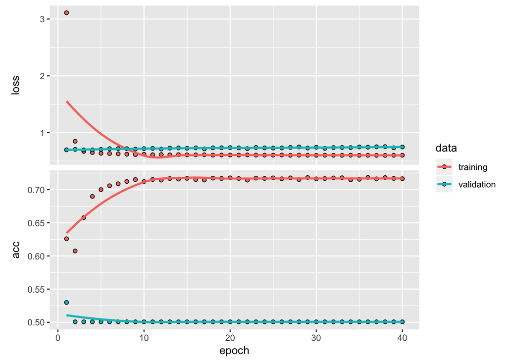

```r
#Save accuracy/loss metrics as dataframe
hist_df <- hist$metrics %>% as_data_frame()
# Use generic plot function to plot accuracy/loss metrics in ggplot
plot(hist)
```